# Programming in Python: Lecture 7

Carolyn Jane Anderson

10/28/2017

Today we’re going to talk about a data structure that is very important for linguists: trees. In particular, we’re going to talk about two kinds of trees: binary search trees and tries.

## Binary Search Trees

Binary search trees are aptly named. They are binary trees. And they faciliate searching.

Here is an example of a binary search tree:

[figure not shown]

Source:commons.wikimedia.org/w/index.php?curid=488330.

Each node can have at most two children. The subtree on the left contains only values smaller than the parent, and the subtree on the right contains only values larger than the parent.

This means that when the root node is selected well, you can search a binary search tree for an arbitrary value in logarithmic (O(log n)) time. This makes them much more efficient to search than lists, which take linear time (O(n)).

What is the best case for binary search? When the root node is the median value. That way, at each node, you can halve the search space.

In the worst-case, the root node is either the largest or smallest value, and the tree becomes equivalent to a list.

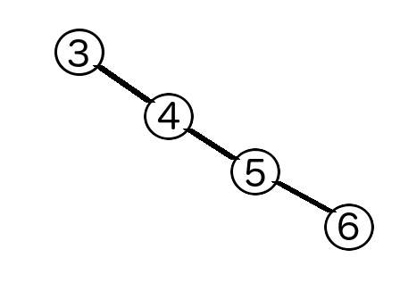

Binary search trees are not a built-in data structure in Python. I’ve written a basic binary search tree class. Don’t worry about the syntax of the class definition: just think of this as a function that takes a list and returns a binary search tree.

Details: If given the empty list, the function returns a BST with no nodes (including no root node). If given a list with duplicates, any duplicates are just ignored.

Today we’re going to write some methods for binary search trees. First of all, it would be good to have a way of printing the tree.

### Printing a binary search tree

Let’s focus first on printing out the structure of the tree. We can add indentation for each level of the tree.

##### See printBST.py

Well, this lets us look inside the tree, but it’s not the most readable. How could we center-print the tree?

##### See printBST.py

That’s much better! But we’re still manually figuring out the height of the tree… which means that if we have a program that prints out a bunch of these, it won’t know what to use as the ind value for each.

Maybe we should add something to keep track of the height of the tree?

##### See height.py

Great, now we can call findHeight, and pass the result as the argument to prettyPrintBST!

### Traversing the tree

Another kind of printing method we might want to have for our binary search tree is printing the values out in order.

This is an *in-order traversal* of the tree.

### Inserting new values into a binary search tree

What do we have to do to insert new values into a binary search tree?

Well, if our value is bigger than the root value, we need to search the right subtree, and insert it there. If it’s smaller, we need to search the left subtree, and insert it there. (What happens if it is equal to the root value?)

This is a perfect kind of problem to solve with a recursive algorithm.

##### See insert.py

(You can also write this iteratively, but it’s a little less intuitive. You can compare our recursive algorithm with the iterative version I wrote in the BST constructor.)

## Tries

The second kind of tree we’re going to talk about is called a *trie*. It’s also known as a prefix tree, because it is most commonly used to store strings. The idea is that each child of the parent stores the string associated with the parent, plus one more character. That is, each level h in the tree stores prefixes of length h.

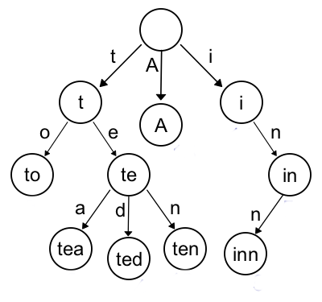

https://commons.wikimedia.org/w/index.php?curid=1197221

The trie above stores terminal nodes containing the words ‘A’, ‘to’, ‘ted’, ‘ten’, ‘tea’, and ‘inn’, as well as parent nodes containing all prefixes of these words.

I’ve implemented a trie in trie.py. Notice that each node only stores one letter, and that prefixes must be read by walking down the branches of the trie.

### Returning all leaves of a trie

One important method to write for our trie class is a function that returns all leaves of the trie. These represent words.

In order to do this, we’ll have to walk down every branch of the trie, building up the word as we go, until we reach a node that has no children (a leaf).

### Get

I’m going to go ahead and add some more built-in methods to our trie, so that we can get to some applications.

In trie+.py, you’ll find an updated version of the trie that has a get() method to find the node containing a given value; getValues(), which returns the values of the immediate children of a given node; and getPrefixes(), which returns all prefixes stored in the trie.

### Spell-check using a trie

Now for some problem-solving using tries! We’re going to write a spell-checker.

First, we need to find some text to build our trie on. We’re going to make the simplifying assumption that any word not occurring in the first 10,000 words of Emma by Jane Austen is not a valid word of English.

Next, we’ll do some preprocessing with the selection from Emma: strip punctuation, make everything lowercase (of course, you might not want to do this— perhaps ‘Emma’ is a valid word, but ‘emma’ is not?), and split the text into a list of words.

Then we read all the words from the text into the trie.

Next, we give our program an argument indicating the file that we want to spell-check. Since we built this trie on data from Emma, let’s use another selection from Emma. I’ve run 500 words from Emma through a program that adds some spelling mistakes. You can find the original text in emma.txt, and the misspelled version in misspelledEmma.txt.

Now let’s write a function that checks whether a word is misspelled.

##### See spellcheck.py

Once we’ve got that, we can simply call it for each word of the text. I’m going to do two things: collect a list of misspellings, and mark misspellings in the text using ‘#’ on either side of the misspelled word.

### Challenge: Can you write a trie-based spell-checker that gives suggestions?

Real spell-checkers suggest corrections for misspelled words. Can you think of how to do that using our trie?